## Reproducible Research: Peer Assessment 1

### Loading and preprocessing the data

**1. Load the data**

```r
unzip("activity.zip")

library("tidyverse")
activity <- read_csv("activity.csv")
```

**2. Process/transform the data (if necessary) into a format suitable for your analysis**  
I didn’t need to transform the data.

### What is mean total number of steps taken per day?

**1. Make a histogram of the total number of steps taken each day**

```r
totalSteps <- activity %>%
                group_by(date) %>%
                  summarize(total = sum(steps))
```

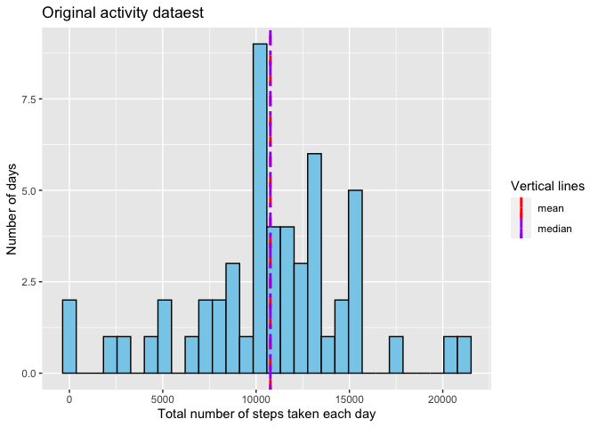

```r
ggplot(data = totalSteps, aes(x = total)) +
  geom_histogram(color = "black", fill = "skyblue") +
  ggtitle("Original activity dataest") +
  xlab("Total number of steps taken each day") +
  ylab("Number of days") +
  geom_vline(aes(xintercept = mean(total, na.rm = TRUE), color = "mean"),
             size = 1,
             linetype = "dashed") +
  geom_vline(aes(xintercept = median(total, na.rm = TRUE), color = "median"),
             size = 1,
             linetype = "twodash") +
  scale_color_manual(name = "Vertical lines",
                     values = c("red", "purple"))
```

**2. Calculate and report the mean and median total number of steps taken per day**

```r
totalSteps %>%
  summarize(mean = mean(total, na.rm = TRUE),
            median = median(total, na.rm = TRUE))
```

```
## # A tibble: 1 x 2
##     mean median
##    <dbl>  <dbl>
## 1 10766.  10765
```

### What is the average daily activity pattern?

**1. Make a time series plot (i.e. type = “l”) of the 5-minute interval (x-axis) and the average number of steps taken, averaged across all days (y-axis)**

```r
averageSteps <- activity %>%
                  group_by(interval) %>%
                    summarize(average = mean(steps, na.rm = TRUE))
```

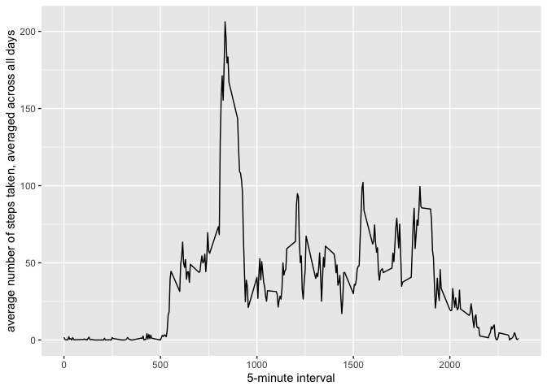

```r
ggplot(data = averageSteps, aes(x = interval, y = average)) +
  geom_line() +
  xlab("5-minute interval") +
  ylab("average number of steps taken, averaged across all days")
```

**2. Which 5-minute interval, on average across all the days in the dataset, contains the maximum number of steps?**

```r
averageSteps %>%
  filter(average == max(average)) %>%
    select(interval)
```

```
## # A tibble: 1 x 1
##   interval
##      <dbl>
## 1      835
```

### Imputing missing values

**1. Calculate and report the total number of missing values in the dataset (i.e. the total number of rows with NAs)**

```r
sapply(activity, function(x) {sum(is.na(x))})
```

```
##    steps     date interval
##     2304        0        0
```

**2. Devise a strategy for filling in all of the missing values in the dataset. The strategy does not need to be sophisticated. For example, you could use the mean/median for that day, or the mean for that 5-minute interval, etc.**

I chose to impute each missing value with the mean for that 5-minute interval. I have previously calculated that in the “What is the average daily activity pattern?” question above (*averageSteps* tibble).

**3. Create a new dataset that is equal to the original dataset but with the missing data filled in.**

```r
activity_imputed <- activity

for (i in 1:length(activity$steps)) {
    if (is.na(activity$steps[i])) {
      activity_imputed$steps[i] <-
        averageSteps[averageSteps$interval==activity$interval[i],]$average
    }
}
```

**4. Make a histogram of the total number of steps taken each day and Calculate and report the mean and median total number of steps taken per day. Do these values differ from the estimates from the first part of the assignment? What is the impact of imputing missing data on the estimates of the total daily number of steps?**

```r
totalSteps2 <- activity_imputed %>%
                group_by(date) %>%
                  summarise(total = sum(steps))
```

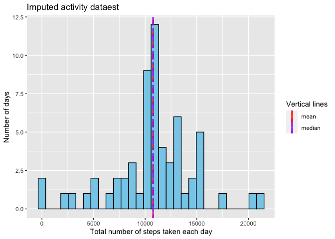

```r
ggplot(data = totalSteps2, aes(x = total)) +
  geom_histogram(color = "black", fill = "skyblue") +
  ggtitle("Imputed activity dataest") +
  xlab("Total number of steps taken each day") +
  ylab("Number of days") +
  geom_vline(aes(xintercept = mean(total), color = "mean"),
             size = 1,
             linetype = "dashed") +
  geom_vline(aes(xintercept = median(total), color = "median"),
             size = 1,
             linetype = "twodash") +
  scale_color_manual(name = "Vertical lines",
                     values = c("red", "purple"))
```

```r
totalSteps2 %>%
  summarize(mean = mean(total),
            median = median(total))
```

```
## # A tibble: 1 x 2
##     mean median
##    <dbl>  <dbl>
## 1 10766. 10766.
```

The *mean* remained the same as I imputed the missing values with the mean. However, the *median* increased just a little (previously it was 10765).

### Are there differences in activity patterns between weekdays and weekends?

**1. Create a new factor variable in the dataset with two levels – “weekday” and “weekend” indicating whether a given date is a weekday or weekend day.**

```r
activity_imputed <- activity_imputed %>%
                      mutate(day = weekdays(date))

weekend <- c("Saturday", "Sunday")

for (i in 1:length(activity_imputed$day)) {
    if (activity_imputed$day[i] %in% weekend) {
      activity_imputed$day[i] <- "weekend"
    }
    else {
      activity_imputed$day[i] <- "weekday"
    }
}

activity_imputed$day <- as.factor(activity_imputed$day)
```

**2. Make a panel plot containing a time series plot (i.e. type = “l”) of the 5-minute interval (x-axis) and the average number of steps taken, averaged across all weekday days or weekend days (y-axis).**

```r
averageSteps2 <- activity_imputed %>%
                  group_by(day, interval) %>%
                    summarize(average = mean(steps))
```

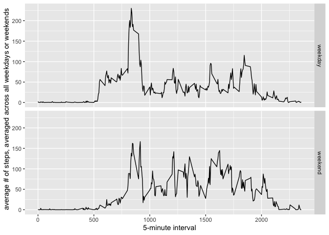

```r
ggplot(data = averageSteps2, aes(x = interval, y = average)) +
  geom_line() +
  facet_grid(rows = vars(day)) +
  xlab("5-minute interval") +
  ylab("average # of steps, averaged across all weekdays or weekends")
```